# Project 1: Wrangling, Exploration, Visualization

SDS322E

## Data Wrangling, Exploration, Visualization

Luis Kim

lyk226

### Introduction

There are three datasets that I will be analyzing today. They are all datasets related to my music listening data.

The first one, which I am calling lastfm, is csv data that I obtained from my [last fm](https://www.last.fm/user/awepi). It contains listening data from February 11, 2020 to October 30, 2021. It has artist names, album names, track names, and the date and time that each track was listened to.

The second one, which I am calling rym, is csv data that I obtained from my [RateYourMusic](https://rateyourmusic.com/~awepi). It contains 489 album ratings. More specifically, it contains a unique album ID, artist names, album titles, album release dates, the rating I gave them (from 1-10), and some other data that is empty and not relevant to me.

The third one, which I am calling rymextra, is data that I scraped manually off of RateYourMusic. It contains various data not included in the csv I exported from rym. It contains the date that I rated each album, the length of each album in H:MM:SS format, the number of tracks on each album, a general genre I have called the genera, and a short list of genres for each album.

The datasets are very dirty on account of them coming from different sources and being split in different ways. They are important to me for obvious reasons (they are my datasets).

```r
# read your datasets in here, e.g., with read_csv()
lastfm <- read.csv("~/project1/data/awepilastfm.csv", col.names = c("Artist",
    "Album", "Track", "DateTime"), stringsAsFactors = F)
lastfm %>% glimpse()
```

```
## Rows: 25,418
## Columns: 4
## $ Artist   <chr> "The Avalanches", "Protomartyr", "Brave Little Abacus", "Tam…
## $ Album    <chr> "We Will Always Love You", "Ultimate Success Today", "Masked…
## $ Track    <chr> "The Divine Chord", "Processed By The Boys", "Underground", …
## $ DateTime <chr> "30 Oct 2021 22:50", "30 Oct 2021 00:54", "30 Oct 2021 00:46…
```

```r
rym <- read.csv("~/project1/data/awepirym.csv", stringsAsFactors = F)
rym %>% glimpse()
```

```
## Rows: 489
## Columns: 12
## $ RYM.Album            <int> 3342137, 9868780, 1736283, 11993342, 432152, 100…
## $ First.Name           <chr> "", "", "", "", "", "", "The", "", "The", "", "L…
## $ Last.Name            <chr> "이소라", "잠비나이", "언니네이발관", "Aesop Rock", "Arctic M…
## $ First.Name.localized <lgl> NA, NA, NA, NA, NA, NA, NA, NA, NA, NA, NA, NA, …
## $ Last.Name.localized  <chr> "Lee So-ra", "Jambinai", "Sister's Barbershop", …
## $ Title                <chr> "7집", "온다 (Onda)", "가장 보통의 존재", "Spirit World Fi…
## $ Release_Date         <int> 2008, 2019, 2008, 2020, 2006, 2019, 1969, 2011, …
## $ Rating               <int> 5, 3, 7, 6, 6, 3, 6, 6, 7, 3, 5, 6, 7, 8, 9, 6, …
## $ Ownership            <chr> "n", "n", "n", "n", "n", "n", "n", "n", "n", "n"…
## $ Purchase.Date        <lgl> NA, NA, NA, NA, NA, NA, NA, NA, NA, NA, NA, NA, …
## $ Media.Type           <lgl> NA, NA, NA, NA, NA, NA, NA, NA, NA, NA, NA, NA, …
## $ Review               <lgl> NA, NA, NA, NA, NA, NA, NA, NA, NA, NA, NA, NA, …
```

```r
rymextra <- read.csv("~/project1/data/rymextra.csv", stringsAsFactors = F)
rymextra %>% glimpse()
```

```
## Rows: 489
## Columns: 7
## $ Artist       <chr> "Richard Dawson", "Richard Dawson", "The Beatles", "The …
## $ Album        <chr> "Peasant", "2020", "Abbey Road", "Pet Sounds", "This Doe…
## $ DateReviewed <chr> "20,1,2", "20,1,2", "20,1,2", "20,1,3", "20,1,3", "20,1,…
## $ Length       <chr> "0:58:46", "0:57:53", "0:47:31", "0:35:01", "0:42:41", "…
## $ TrackNum     <int> 11, 10, 17, 13, 13, 17, 12, 10, 10, 11, 6, 10, 17, 13, 5…
## $ Genera       <chr> "Folk", "Folk", "Pop", "Pop", "Hip Hop", "Electronic", "…
## $ Genres       <chr> "Progressive Folk, Avant-Folk", "Art Rock, Singer/Songwr…
```

### Wrangling, Part 1

I am adding this extra section because I want to do a little wrangling before I join these datasets together.

I will start with rym, the dirtiest dataset in the bunch. First, I trim some columns and combine the First.Name and Last.Name columns into one column: Artist.

```r
rym <- rym %>% select(-Ownership, -Purchase.Date, -Media.Type,
    -Review) %>% mutate(Artist = trimws(str_c(First.Name, Last.Name,
    sep = " "))) %>% select(-First.Name, -Last.Name)
```

I’m also going to get rid of the localized names, because they are very poorly managed on RYM. I will deal with that in a bit.

```r
rym <- rym %>% select(-First.Name.localized, -Last.Name.localized)
```

I also want to rename Title to Album for easier joining later.

```r
rym <- rym %>% rename(Album = Title)
rym %>% glimpse()
```

```
## Rows: 489
## Columns: 5
## $ RYM.Album    <int> 3342137, 9868780, 1736283, 11993342, 432152, 10038193, 2…
## $ Album        <chr> "7집", "온다 (Onda)", "가장 보통의 존재", "Spirit World Field Guid…
## $ Release_Date <int> 2008, 2019, 2008, 2020, 2006, 2019, 1969, 2011, 1969, 20…
## $ Rating       <int> 5, 3, 7, 6, 6, 3, 6, 6, 7, 3, 5, 6, 7, 8, 9, 6, 5, 4, 5,…
## $ Artist       <chr> "이소라", "잠비나이", "언니네이발관", "Aesop Rock", "Arctic Monkeys",…
```

Then, I will deal with rymextra. First, I want to split up DateReviewed.

```r
rymextra <- rymextra %>% separate(DateReviewed, into = c("YearRev",
    "MonthRev", "DayRev"), sep = ",")
```

And I want to split up Genres.

```r
rymextra <- rymextra %>% separate(Genres, into = c("Genre1",
    "Genre2", "Genre3", "Genre4"), sep = ", ")
```

```r
glimpse(rymextra)
```

```
## Rows: 489
## Columns: 12
## $ Artist   <chr> "Richard Dawson", "Richard Dawson", "The Beatles", "The Beac…
## $ Album    <chr> "Peasant", "2020", "Abbey Road", "Pet Sounds", "This Does No…
## $ YearRev  <chr> "20", "20", "20", "20", "20", "20", "20", "20", "20", "20", …
## $ MonthRev <chr> "1", "1", "1", "1", "1", "1", "1", "1", "1", "1", "1", "1", …
## $ DayRev   <chr> "2", "2", "2", "3", "3", "4", "6", "6", "7", "8", "11", "11"…
## $ Length   <chr> "0:58:46", "0:57:53", "0:47:31", "0:35:01", "0:42:41", "0:38…
## $ TrackNum <int> 11, 10, 17, 13, 13, 17, 12, 10, 10, 11, 6, 10, 17, 13, 5, 14…
## $ Genera   <chr> "Folk", "Folk", "Pop", "Pop", "Hip Hop", "Electronic", "Elec…
## $ Genre1   <chr> "Progressive Folk", "Art Rock", "Pop Rock", "Baroque Pop", "…
## $ Genre2   <chr> "Avant-Folk", "Singer/Songwriter", NA, NA, NA, NA, "Experime…
## $ Genre3   <chr> NA, NA, NA, NA, NA, NA, NA, "Contemporary Folk", NA, NA, NA,…
## $ Genre4   <chr> NA, NA, NA, NA, NA, NA, NA, NA, NA, NA, NA, NA, NA, NA, NA, …
```

There are two albums named Shrines. I am going to distinguish these into “Shrines (AH)” and “Shrines (PR)” in each dataframe.

```r
lastfm[lastfm$Album == "Shrines" & lastfm$Artist == "Armand Hammer",
    ]$Album <- "Shrines (AH)"
lastfm[lastfm$Album == "Shrines" & lastfm$Artist == "Purity Ring",
    ]$Album <- "Shrines (PR)"
rym[rym$Album == "Shrines" & rym$Artist == "Armand Hammer", ]$Album <- "Shrines (AH)"
rym[rym$Album == "Shrines" & rym$Artist == "Purity Ring", ]$Album <- "Shrines (PR)"
rymextra[rymextra$Album == "Shrines" & rymextra$Artist == "Armand Hammer",
    ]$Album <- "Shrines (AH)"
rymextra[rymextra$Album == "Shrines" & rymextra$Artist == "Purity Ring",
    ]$Album <- "Shrines (PR)"
```

Also, lastfm has two albums named II. I am going to distinguish these into “TNGHT II” and “Meat Puppets II”.

```r
lastfm[lastfm$Album == "II" & lastfm$Artist == "TNGHT", ]$Album <- "TNGHT II"
lastfm[lastfm$Album == "II" & lastfm$Artist == "Meat Puppets",
    ]$Album <- "Meat Puppets II"
```

There are also a number of strange name changes and duplicate album names that show up later. I amend them here:

```r
lastfm[lastfm$Album == "Kamikaze" & lastfm$Artist == "Paul Rosenberg",
    ]$Album <- "Kamikaze (PR)"
lastfm[lastfm$Album == "밑", ]$Artist <- "PANIC"
lastfm[lastfm$Album == "사랑하기 때문에", ]$Artist <- "Yoo Jae-Ha"
lastfm[lastfm$Album == "2012", ]$Artist <- "mukimukimanmansu"
lastfm[lastfm$Album == "ALL BITCHES DIE", ]$Artist <- "Lingua Ignota"
lastfm[lastfm$Album == "CALIGULA", ]$Artist <- "Lingua Ignota"
lastfm[lastfm$Album == "Dark Lane Demo Tapes", ]$Artist <- "Drake"
lastfm[lastfm$Album == "Flower Boy", ]$Artist <- "Tyler The Creator"
lastfm[lastfm$Album == "Hi This Is Flume (Mixtape)", ]$Artist <- "Flume"
lastfm[lastfm$Album == "How can I", ]$Artist <- "박혜진 Park Hye Jin"
lastfm[lastfm$Album == "I LIE HERE BURIED WITH MY RINGS AND MY DRESSES",
    ]$Artist <- "Backxwash"
lastfm[lastfm$Album == "Joy as an Act of Resistance.", ]$Artist <- "IDLES"
lastfm[lastfm$Album == "Lifes Like", ]$Artist <- "Jazzyfact"
lastfm[lastfm$Album == "Max & Match", ]$Artist <- "LOOΠΔ / ODD EYE CIRCLE"
lastfm[lastfm$Album == "The Anecdote", ]$Artist <- "E SENS"
lastfm[lastfm$Album == "The College Dropout", ]$Artist <- "Kanye West"
lastfm[lastfm$Album == "Traveller" & lastfm$Artist == "Chris Stapleton",
    ]$Album <- "Traveller (CS)"
lastfm[lastfm$Album == "Ultra Mono", ]$Artist <- "IDLES"
lastfm[lastfm$Album == "Whole Lotta Red" & lastfm$Artist == "Mario Judah",
    ]$Album <- "Whole Lotta Red (MJ)"
lastfm[lastfm$Album == "Rodeo (expanded edition)", ]$Artist <- "Travis Scott"
lastfm[lastfm$Album == "Ummon", ]$Artist <- "SLIFT"
```

Now, I will tidy the lastfm data. First, I want the date/time in a better format to work with. I’m going to save each of the date/times as a date datatype.

```r
mths = c("Jan", "Feb", "Mar", "Apr", "May", "Jun", "Jul", "Aug",
    "Sep", "Oct", "Nov", "Dec")
lastfm <- lastfm %>% separate(DateTime, into = c("Day", "Month",
    "Year", "Time"), sep = " ") %>% mutate(Month = match(Month,
    mths)) %>% mutate(Date = as.Date(str_c(Year, Month, Day,
    sep = "-"))) %>% select(Artist, Album, Track, Date)
```

Taking a look at a histogram of this refactored Date variable, one can see that my lastfm cut out unexpectedly from around August 2020 to September 2020.

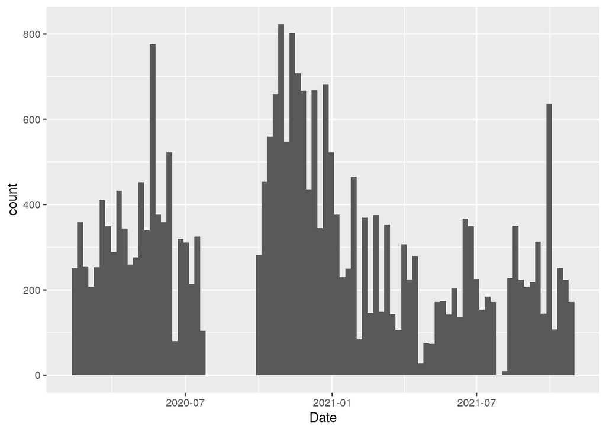

```r
lastfm %>% ggplot(aes(x = Date)) + geom_histogram(binwidth = 7)
```

Anyway, I don’t want all of this data, and I want it by album, so I will group by album and then save the number of times each track was played and a list containing the date and times they were played.

```r
lastfm_wide <- lastfm %>% group_by(Artist, Album) %>% summarize(PlayCount = n(),
    PlayTimes = list(Date))
lastfm_wide %>% glimpse()
```

```
## Rows: 685
## Columns: 4
## Groups: Artist [504]
## $ Artist    <chr> "100 gecs", "100 gecs", "100 gecs", "24kGoldn", "645AR", "7…
## $ Album     <chr> "1000 gecs", "1000 gecs and The Tree of Clues", "ringtone (…
## $ PlayCount <int> 73, 1, 3, 1, 1, 1, 1, 3, 54, 36, 2, 44, 83, 43, 16, 88, 48,…
## $ PlayTimes <list> [<2021-09-25, 2021-09-19, 2021-09-12, 2021-09-12, 2021-09-…
```

### Tidying: Reshaping

If your datasets are tidy already, demonstrate that you can reshape data with pivot wider/longer here (e.g., untidy and then retidy). Alternatively, it may be easier to wait until the wrangling section so you can reshape your summary statistics. Note here if you are going to do this.

```r
rymextralong <- rymextra %>% pivot_longer(Genre1:Genre4, values_to = "Genre") %>%
    filter(!is.na(Genre))
rymextralong %>% slice_head(n = 10)
```

```
## # A tibble: 10 x 10
##    Artist   Album   YearRev MonthRev DayRev Length TrackNum Genera name  Genre
##    <chr>    <chr>   <chr>   <chr>    <chr>  <chr>     <int> <chr>  <chr> <chr>
##  1 Richard… Peasant 20      1        2      0:58:…       11 Folk   Genr… Progre…
##  2 Richard… Peasant 20      1        2      0:58:…       11 Folk   Genr… Avant-…
##  3 Richard… 2020    20      1        2      0:57:…       10 Folk   Genr… Art Ro…
##  4 Richard… 2020    20      1        2      0:57:…       10 Folk   Genr… Singer…
##  5 The Bea… Abbey … 20      1        2      0:47:…       17 Pop    Genr… Pop Ro…
##  6 The Bea… Pet So… 20      1        3      0:35:…       13 Pop    Genr… Baroqu…
##  7 Lil Dar… This D… 20      1        3      0:42:…       13 Hip H… Genr… Experi…
##  8 Flume    Hi Thi… 20      1        4      0:38:…       17 Elect… Genr… Wonky
##  9 Stice    Here C… 20      1        6      0:21:…       12 Elect… Genr… Digita…
## 10 Stice    Here C… 20      1        6      0:21:…       12 Elect… Genr… Experi…
```

I will do this sort of tidying when computing genre related statistics.

### Joining/Merging

We want to join rym and rymextra together. They should theoretically completely agree on Artist and Album, namely Album. They’re each 489 rows, with one row per album. I will check for any discrepancies between the album lists first.

```r
rym$Album[!(rym$Album %in% rymextra$Album)]
```

```
##  [1] "Everywhere at the End of Time: Stage 1"
##  [2] "Everywhere at the End of Time: Stage 2"
##  [3] "Everywhere at the End of Time: Stage 3"
##  [4] "Everywhere at the End of Time: Stage 4"
##  [5] "Everywhere at the End of Time: Stage 5"
##  [6] "No Love Deep Web"
##  [7] "1000 Gecs"
##  [8] "&#34;Disco!&#34;"
##  [9] "Chat-Shire"
## [10] "Damn."
## [11] "Daytona"
## [12] "Everywhere at the End of Time: Stage 6"
## [13] "Fishmonger"
## [14] "iridescence"
## [15] "JESUS IS KING"
## [16] "KIDS SEE GHOSTS"
## [17] "Put Your Back n 2 It"
## [18] "SAWAYAMA"
## [19] "Untitled Unmastered."
## [20] "Wide Awake"
## [21] "Worry."
```

```r
rymextra$Album[!(rymextra$Album %in% rym$Album)]
```

```
##  [1] "DAYTONA"
##  [2] "1000 gecs"
##  [3] "Sawayama"
##  [4] "Iridescence"
##  [5] "WORRY."
##  [6] "Everywhere at the End of Time - Stage 6"
##  [7] "Everywhere at the End of Time - Stage 5"
##  [8] "Everywhere at the End of Time - Stage 4"
##  [9] "Everywhere at the End of Time - Stage 3"
## [10] "Everywhere at the End of Time - Stage 2"
## [11] "Everywhere at the End of Time - Stage 1"
## [12] "fishmonger"
## [13] "Disco!"
## [14] "Chat-shire"
## [15] "untitled unmastered."
## [16] "DAMN."
## [17] "Jesus Is King"
## [18] "NO LOVE DEEP WEB"
## [19] "Put Your Back N 2 It"
## [20] "Kids See Ghosts"
## [21] "Wide Awake!"
```

You can see there are various spelling discrepancies. Since there are not *that* many, I’ve decided to go ahead and fix them manually in the code chunk below.

```r
rymextra <- rymextra %>% mutate(Album = str_replace(Album, "Time -",
    "Time:")) %>% mutate(Album = str_replace(Album, "Sawayama",
    "SAWAYAMA")) %>% mutate(Album = str_replace(Album, "Kids See Ghosts",
    "KIDS SEE GHOSTS")) %>% mutate(Album = str_replace(Album,
    "Jesus Is King", "JESUS IS KING")) %>% mutate(Album = str_replace(Album,
    "Iridescence", "iridescence")) %>% mutate(Album = str_replace(Album,
    "Chat-shire", "Chat-Shire"))
rym <- rym %>% mutate(Album = str_replace(Album, "Wide Awake",
    "Wide Awake!")) %>% mutate(Album = str_replace(Album, "Damn.",
    "DAMN.")) %>% mutate(Album = str_replace(Album, "Untitled Unmastered.",
    "untitled unmastered.")) %>% mutate(Album = str_replace(Album,
    "Worry.", "WORRY.")) %>% mutate(Album = str_replace(Album,
    "1000 Gecs", "1000 gecs")) %>% mutate(Album = str_replace(Album,
    "No Love Deep Web", "NO LOVE DEEP WEB")) %>% mutate(Album = str_replace(Album,
    "Fishmonger", "fishmonger")) %>% mutate(Album = str_replace(Album,
    "&#34;Disco!&#34;", "Disco!")) %>% mutate(Album = str_replace(Album,
    "Daytona", "DAYTONA")) %>% mutate(Album = str_replace(Album,
    "Put Your Back n 2 It", "Put Your Back N 2 It"))
```

The code has run, now:

```r
rym$Album[!(rym$Album %in% rymextra$Album)]
```

```
## character(0)
```

```r
rymextra$Album[!(rymextra$Album %in% rym$Album)]
```

```
## character(0)
```

is empty. We are ready to join.

```r
rym_full <- full_join(rym, rymextra, by = c("Album"))
rym_full %>% slice_head(n = 10)
```

```
##   RYM.Album                                         Album Release_Date Rating
## 1   3342137                                           7집         2008      5
## 2   9868780                                   온다 (Onda)         2019      3
## 3   1736283                              가장 보통의 존재         2008      7
## 4  11993342                      Spirit World Field Guide         2020      6
## 5    432152 Whatever People Say I Am, That's What I'm Not         2006      6
## 6  10038193                                  OK, I'm Sick         2019      3
##         Artist.x       Artist.y YearRev MonthRev DayRev  Length TrackNum
## 1         이소라         이소라      20       11     13 0:58:15       13
## 2       잠비나이       잠비나이      20       10     21 0:50:29        8
## 3   언니네이발관   언니네이발관      20        6     27 0:43:41       10
## 4     Aesop Rock     Aesop Rock      20       12     25 1:03:06       21
## 5 Arctic Monkeys Arctic Monkeys      20       10      5 0:40:58       13
## 6      Badflower      Badflower      20        2     26 0:55:28       13
##    Genera           Genre1              Genre2 Genre3 Genre4
## 1     Pop         Pop Rock                <NA>   <NA>   <NA>
## 2    Rock        Post-Rock                <NA>   <NA>   <NA>
## 3    Rock         Pop Rock          Indie Rock   <NA>   <NA>
## 4 Hip Hop Abstract Hip Hop                <NA>   <NA>   <NA>
## 5    Rock       Indie Rock Garage Rock Revival   <NA>   <NA>
## 6    Rock Alternative Rock                <NA>   <NA>   <NA>
##  [ reached 'max' / getOption("max.print") -- omitted 4 rows ]
```

```r
nrow(rym_full)
```

```
## [1] 489
```

You can see our result is 489 rows long, which indicates that our join was smooth and successful.

```r
rym_full %>% filter(Artist.x != Artist.y) %>% select(Artist.x,
    Artist.y)
```

```
##                            Artist.x                           Artist.y
## 1       Godspeed You! Black Emperor        Godspeed You Black Emperor!
## 2                          100 Gecs                           100 gecs
## 3                     Lingua Ignota                      LINGUA IGNOTA
## 4                       Underscores                        underscores
## 5 I DONT KNOW HOW BUT THEY FOUND ME I Don't Know How But They Found Me
## 6                   At the Drive-In                    At The Drive-In
## 7                         The Kniφe                         The KniÏ†e
## 8                        Deafheaven                          Deafhaven
## 9                Jay-Z & Kanye West                 JAY Z & Kanye West
```

There is annoying collection of artist discrepancies which I will, once again, fix manually and discreetly.

```r
rym_full <- rym_full %>% mutate(Artist.x = str_replace(Artist.x,
    "100 Gecs", "100 gecs")) %>% mutate(Artist.x = str_replace(Artist.x,
    "Underscores", "underscores")) %>% mutate(Artist.x = str_replace(Artist.x,
    "At the Drive-In", "At The Drive-In")) %>% mutate(Artist.x = str_replace(Artist.x,
    "The Kniφe", "The Knife"))
```

```r
rym_full %>% filter(Artist.x != Artist.y) %>% select(Artist.x,
    Artist.y)
```

```
##                            Artist.x                           Artist.y
## 1       Godspeed You! Black Emperor        Godspeed You Black Emperor!
## 2                     Lingua Ignota                      LINGUA IGNOTA
## 3                       underscores                        Underscores
## 4 I DONT KNOW HOW BUT THEY FOUND ME I Don't Know How But They Found Me
## 5                         The Knife                         The KniÏ†e
## 6                       underscores                        Underscores
## 7                        Deafheaven                          Deafhaven
## 8                Jay-Z & Kanye West                 JAY Z & Kanye West
## 9                       underscores                        Underscores
```

rym_full still has weird discrepancies, but I’ve saved all of the preferred, Spotify consistent artist names to Artist.x, which I will make the main and only artist column.

```r
rym_full <- rym_full %>% rename(Artist = Artist.x) %>% select(-Artist.y)
```

Next up, we want to attach the lastfm data to rym_full. This is difficult because a lot of album names are not consistent across RYM and Spotify. As a result, I’ve manually made a CSV with the RYM and Spotify names for each album.

```r
namematch <- read.csv("~/project1/data/namematch.csv", stringsAsFactors = FALSE)
namematch %>% glimpse()
```

```
## Rows: 489
## Columns: 2
## $ RYM    <chr> "7집", "온다 (Onda)", "가장 보통의 존재", "Spirit World Field Guide", "W…
## $ LASTFM <chr> "N/A", "Onda", "가장 보통의 존재 Most Ordinary Existence", "Spirit Wo…
```

To join lastfm to rym_full, I will first join namematch to rym_full, and then join lastfm_wide to the result.

```r
rym_full <- full_join(rym_full, namematch, by = c(Album = "RYM"))
data_full <- left_join(rym_full, lastfm_wide, by = c(LASTFM = "Album"))
data_full %>% select(Album, Artist.x, PlayCount) %>% slice_head(n = 10)
```

```
##                                            Album       Artist.x PlayCount
## 1                                            7집         이소라        NA
## 2                                    온다 (Onda)       잠비나이        19
## 3                               가장 보통의 존재   언니네이발관        81
## 4                       Spirit World Field Guide     Aesop Rock        83
## 5  Whatever People Say I Am, That's What I'm Not Arctic Monkeys        23
## 6                                   OK, I'm Sick      Badflower        19
## 7                                       The Band       The Band        43
## 8                   Hot Sauce Committee Part Two   Beastie Boys        18
## 9                                     Abbey Road    The Beatles        25
## 10                            Map of the Soul: 7            BTS         1
```

```r
nrow(data_full)
```

```
## [1] 489
```

I performed a left join here because I want to associate the lastfm data to the data that I have from RYM, not the other way around. Our resulting dataset has the same number of rows, 489, as our RYM dataset for this reason.

### Wrangling

I will start with a little tidying of residue from that join that just happened.

```r
data_full <- data_full %>% rename(Artist = Artist.x) %>% select(-Artist.y,
    -RYM.Album, -LASTFM)
data_full <- data_full %>% relocate(Artist)
data_full %>% select(Artist:PlayCount) %>% slice_head(n = 10)
```

```
##           Artist                                         Album Release_Date
## 1         이소라                                           7집         2008
## 2       잠비나이                                   온다 (Onda)         2019
## 3   언니네이발관                              가장 보통의 존재         2008
## 4     Aesop Rock                      Spirit World Field Guide         2020
## 5 Arctic Monkeys Whatever People Say I Am, That's What I'm Not         2006
## 6      Badflower                                  OK, I'm Sick         2019
##   Rating YearRev MonthRev DayRev  Length TrackNum  Genera           Genre1
## 1      5      20       11     13 0:58:15       13     Pop         Pop Rock
## 2      3      20       10     21 0:50:29        8    Rock        Post-Rock
## 3      7      20        6     27 0:43:41       10    Rock         Pop Rock
## 4      6      20       12     25 1:03:06       21 Hip Hop Abstract Hip Hop
## 5      6      20       10      5 0:40:58       13    Rock       Indie Rock
## 6      3      20        2     26 0:55:28       13    Rock Alternative Rock
##                Genre2 Genre3 Genre4 PlayCount
## 1                <NA>   <NA>   <NA>        NA
## 2                <NA>   <NA>   <NA>        19
## 3          Indie Rock   <NA>   <NA>        81
## 4                <NA>   <NA>   <NA>        83
## 5 Garage Rock Revival   <NA>   <NA>        23
## 6                <NA>   <NA>   <NA>        19
##  [ reached 'max' / getOption("max.print") -- omitted 4 rows ]
```

Now, some summary statistics.

There are 489 distinct albums in the dataset.

##### Release Dates

```r
data_full %>% group_by(Release_Date) %>% summarize(n = n()) %>%
    arrange(desc(n)) %>% slice_head(n = 10)
```

```
## # A tibble: 10 x 2
##    Release_Date     n
##           <int> <int>
##  1         2020   130
##  2         2019    39
##  3         2018    23
##  4         2010    18
##  5         2017    18
##  6         2012    16
##  7         2015    16
##  8         2021    16
##  9         2016    15
## 10         2014    11
```

Most albums I have reviewed were released in 2020, with 2019 and 2018 coming in next. We may also want to see the frequency counts by decade.

```r
data_full %>% mutate(Decade = floor(Release_Date/10) * 10) %>%
    group_by(Decade) %>% summarize(n = n()) %>% arrange(desc(n))
```

```
## # A tibble: 8 x 2
##   Decade     n
##    <dbl> <int>
## 1   2010   176
## 2   2020   146
## 3   2000    55
## 4   1990    43
## 5   1980    28
## 6   1970    25
## 7   1960    14
## 8   1950     2
```

We can see that overall, most of the albums I have reviewed are from the 2010s by a slim margin. The 2020s are runner up, slowly overtaking the 2010s, with recent decades following in the rankings after that.

##### Ratings

Let’s look at some ratings.

```r
data_full %>% summarize(mean(Rating), sd(Rating), median(Rating))
```

```
##   mean(Rating) sd(Rating) median(Rating)
## 1     6.447853   1.693115              7
```

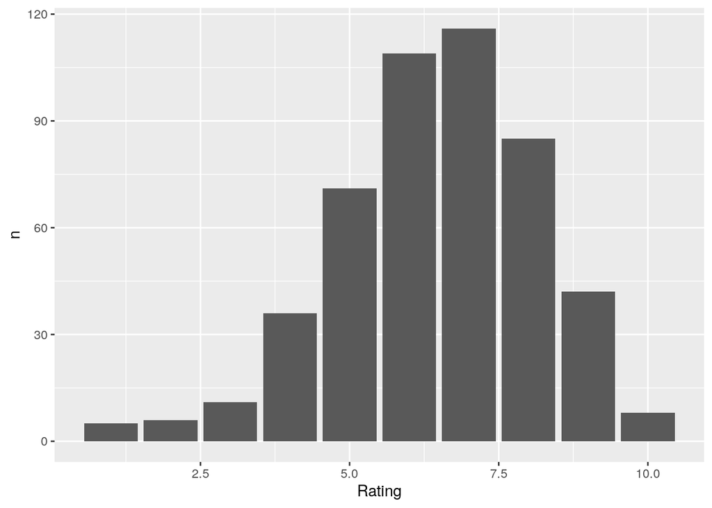

```r
data_full %>% group_by(Rating) %>% summarize(n = n()) %>% ggplot(aes(x = Rating,
    y = n)) + geom_bar(stat = "identity")
```

The average rating is 6.44, and the standard deviation of the ratings is 1.693. There is a fairly normal, slightly left-skewed distribution of ratings, with median at 7.

##### Rating Dates

```r
data_full %>% group_by(YearRev) %>% summarize(n = n())
```

```
## # A tibble: 3 x 2
##   YearRev     n
##   <chr>   <int>
## 1 19         93
## 2 20        366
## 3 21         30
```

Most of the ratings were assigned during 2020, when I did an album a day challenge. This challenge wasn’t really consistent though. The next frequency table shows that there was a lot of cramming done in December of 2020, where I made up all of the lost ground by listening to 66 albums in one month, barely bringing me up to the 366 days of that year.

```r
data_full %>% group_by(YearRev, MonthRev) %>% summarize(num = n()) %>%
    arrange(desc(num)) %>% slice_max(order_by = num)
```

```
## # A tibble: 3 x 3
## # Groups:   YearRev [3]
##   YearRev MonthRev   num
##   <chr>   <chr>    <int>
## 1 19      11          63
## 2 20      12          66
## 3 21      7            8
```

```r
data_full %>% group_by(YearRev, MonthRev, DayRev) %>% summarize(n = n()) %>%
    arrange(desc(n)) %>% ungroup() %>% slice_head(n = 10)
```

```
## # A tibble: 10 x 4
##    YearRev MonthRev DayRev     n
##    <chr>   <chr>    <chr>  <int>
##  1 19      11       18        44
##  2 20      12       2          6
##  3 20      12       31         6
##  4 20      10       12         5
##  5 20      12       25         5
##  6 20      12       28         5
##  7 20      2        9          5
##  8 20      10       21         4
##  9 20      10       29         4
## 10 20      11       1          4
```

The day frequencies reveal that I inputted a bunch of ratings on the day that I began this RYM account, which was 2019 November 18. Of the next highest frequencies, 4 of them are in December of 2020, reflecting the cramming that happened that month. 5 albums rated on Christmas!

##### Album Length

I’m going to want to deal with these times in a numerical format. We will need to do some refactoring. I am aware there is a cleaner way to do this, but for the requirement I will define a custom function to take each album length and turn it into a number in terms of minutes.

```r
conv_to_mins <- function(x) {
    splitx <- as.numeric(unlist(str_split(x, ":")))
    60 * splitx[1] + splitx[2] + splitx[3]/60
}
conv_to_time <- function(x) {
    str_c(floor(x/60), ":", formatC(floor(x%%60), 1, flag = "0",
        format = "d"), ":", formatC(round(60 * (x%%1)), 1, flag = "0",
        format = "d"))
}

data_full %>% mutate(LengthNum = sapply(Length, conv_to_mins)) %>%
    summarize(TotalLength = conv_to_time(sum(LengthNum)), AvgLength = conv_to_time(mean(LengthNum)),
        MedianLength = conv_to_time(median(LengthNum)))
```

```
##   TotalLength AvgLength MedianLength
## 1   390:26:38   0:47:54      0:45:09
```

This album listening data constitutes 390 total hours of listening, with the average album being 47 minutes long, and the median album being 45 minutes long.

```r
data_full %>% mutate(LengthNum = sapply(Length, conv_to_mins)) %>%
    arrange(desc(LengthNum)) %>% select(Artist, Album, Rating,
    Length, TrackNum, Genera, PlayCount) %>% slice_head(n = 5)
```

```
##                 Artist           Album Rating  Length TrackNum Genera PlayCount
## 1    Kamasi Washington        The Epic      7 2:53:33       21   Jazz        NA
## 2 Neptunian Maximalism            Éons      5 2:08:21       16   Rock        43
## 3                Swans      To Be Kind      9 2:01:12       10   Rock        29
## 4                Swans The Glowing Man      9 1:59:20        8   Rock        12
## 5                Swans        The Seer      9 1:58:58       11   Rock        41
```

```r
data_full %>% mutate(LengthNum = sapply(Length, conv_to_mins)) %>%
    arrange(LengthNum) %>% select(Artist, Album, Rating, Length,
    TrackNum, Genera, PlayCount) %>% slice_head(n = 5)
```

```
##        Artist
## 1 underscores
## 2    Sungazer
## 3 underscores
## 4       Nails
## 5    Ada Rook
##                                                                      Album
## 1                                             We Never Got Strawberry Cake
## 2                                                          Sungazer Vol. I
## 3                                                   Character Development!
## 4                                                           Unsilent Death
## 5 Separated From Her Twin, a Dying Android Arrives on a Mysterious Island.
##   Rating  Length TrackNum     Genera PlayCount
## 1      6 0:09:30        3        R&B         2
## 2      4 0:09:42        5 Electronic         5
## 3      5 0:09:47        3 Electronic        NA
## 4      7 0:13:58       10       Rock        16
## 5      5 0:14:07        4 Electronic        NA
```

The longest album I listened to was Kamasi Washington’s The Epic, clocking in at a very long 2 hours 53 minutes. The shortest album I listened to was underscores’ EP We Never Got Strawberry Cake, clocking in at just 9 minutes and 30 seconds.

##### Track Number

```r
data_full %>% summarize(TotalTracks = sum(TrackNum), AvgTracks = mean(TrackNum),
    MedianTracks = median(TrackNum))
```

```
##   TotalTracks AvgTracks MedianTracks
## 1        5786  11.83231           11
```

The albums in the dataset constitute a total of 5786 tracks. The average number of tracks per album is 11.83, and the median number of tracks per album is 11.

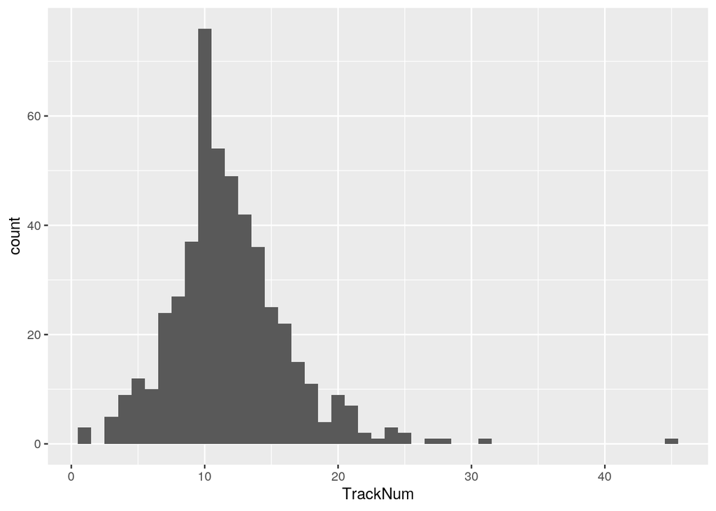

```r
data_full %>% ggplot(aes(x = TrackNum)) + geom_histogram(binwidth = 1)
```

##### Track Length

I’m going to save the average track length of each album into a new column called TrackLength. I will do so by dividing the length of each album by the number of tracks.

```r
data_full <- data_full %>% mutate(LengthNum = sapply(Length,
    conv_to_mins)) %>% mutate(TrackLength = conv_to_time(LengthNum/TrackNum)) %>%
    select(-LengthNum)
```

Here are some summary statistics about average track length:

```r
data_full %>% mutate(LengthNum = sapply(Length, conv_to_mins),
    TrackLengthNum = sapply(TrackLength, conv_to_mins)) %>% summarize(AvgTrackLength = conv_to_time(sum(LengthNum)/sum(TrackNum)),
    AvgAvgTrackLength = conv_to_time(mean(TrackLengthNum)))
```

```
##   AvgTrackLength AvgAvgTrackLength
## 1        0:04:03           0:04:42
```

The average track length of all of these albums is 4 minutes 3 seconds. The average average track length of each album is 4 minutes and 42 seconds.

```r
data_full %>% mutate(TrackLengthNum = sapply(TrackLength, conv_to_mins)) %>%
    arrange(desc(TrackLengthNum)) %>% select(Artist, Album, Rating,
    Length, TrackNum, TrackLength, Genera, PlayCount) %>% slice_head(n = 5)
```

```
##            Artist                                  Album Rating  Length
## 1     Steve Reich                 Music for 18 Musicians      6 0:58:55
## 2 The Microphones                    Microphones in 2020      8 0:44:44
## 3        Fishmans                            Long Season      7 0:35:16
## 4   The Caretaker Everywhere at the End of Time: Stage 5      6 1:28:19
## 5   The Caretaker Everywhere at the End of Time: Stage 4      9 1:27:19
##   TrackNum TrackLength    Genera PlayCount
## 1        1     0:58:55 Classical         1
## 2        1     0:44:44      Folk        NA
## 3        1     0:35:16       Pop         2
## 4        4     0:22:05   Ambient        NA
## 5        4     0:21:50   Ambient        NA
```

```r
data_full %>% mutate(TrackLengthNum = sapply(TrackLength, conv_to_mins)) %>%
    arrange(TrackLengthNum) %>% select(Artist, Album, Rating,
    Length, TrackNum, TrackLength, Genera, PlayCount) %>% slice_head(n = 5)
```

```
##               Artist                               Album Rating  Length
## 1 Miasmatic Necrosis                        Apex Profane      6 0:21:58
## 2            J Dilla                              Donuts      9 0:43:21
## 3              Nails                      Unsilent Death      7 0:13:58
## 4             Orchid Dance Tonight! Revolution Tomorrow!      9 0:15:38
## 5    Earl Sweatshirt                      Some Rap Songs      8 0:24:39
##   TrackNum TrackLength  Genera PlayCount
## 1       21     0:01:03    Rock        55
## 2       31     0:01:24 Hip Hop       509
## 3       10     0:01:24    Rock        16
## 4       10     0:01:34    Rock        87
## 5       15     0:01:39 Hip Hop       108
```

The album with the longest average track length is Steve Reich’s Music for 18 Musicians, which consists of a single 58 minute track. The album with the longest average track length that doesn’t just have one track is The Caretaker’s Everywhere at the End of Time: Stage 5, which is 1 hour 28 minutes long and has 4 tracks. The album with the shortest average track length is Miasmatic Necrosis with Apex Profane, which clocks in at 21 minutes 58 seconds with 21 tracks, making each track barely longer than a minute on average.

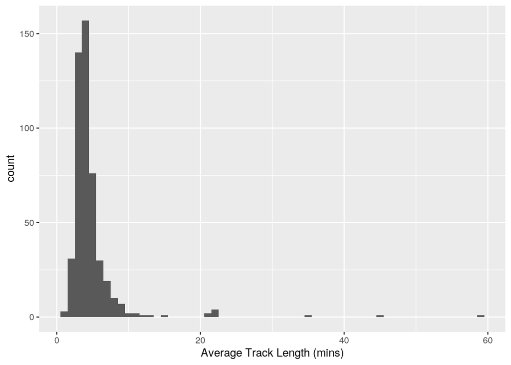

```r
data_full %>% mutate(TrackLengthNum = sapply(TrackLength, conv_to_mins)) %>%
    ggplot(aes(x = TrackLengthNum)) + geom_histogram(binwidth = 1) +
    xlab("Average Track Length (mins)")
```

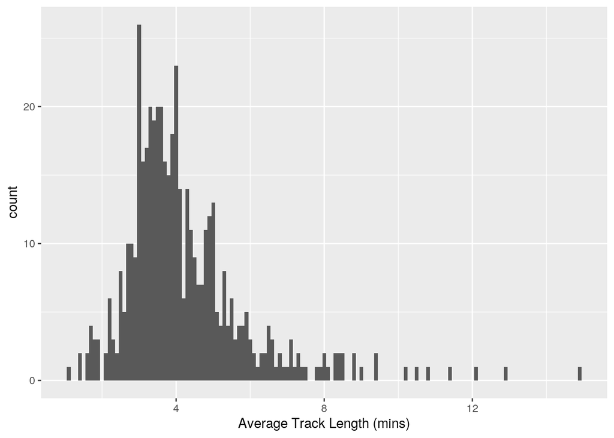

```r
data_full %>% mutate(TrackLengthNum = sapply(TrackLength, conv_to_mins)) %>%
    filter(TrackLengthNum < 20) %>% ggplot(aes(x = TrackLengthNum)) +
    geom_histogram(binwidth = 0.1) + xlab("Average Track Length (mins)")
```

##### Generic Genre

```r
unique(data_full$Genera)
```

```
##  [1] "Pop"                  "Rock"                 "Hip Hop"
##  [4] "Ambient"              "Electronic"           "Folk"
##  [7] "Funk"                 "R&B"                  "Darkwave"
## [10] "Noise"                "Jazz"                 "Experimental"
## [13] "Industrial"           "Soul"                 "Latin American Music"
## [16] ""                     "Country"              "Classical"
```

The albums are classified under 17 unique general genres.

```r
data_full %>% filter(Genera != "") %>% group_by(Genera) %>% summarize(Count = n()) %>%
    arrange(desc(Count))
```

```
## # A tibble: 17 x 2
##    Genera               Count
##    <chr>                <int>
##  1 Rock                   159
##  2 Hip Hop                103
##  3 Pop                     95
##  4 Electronic              40
##  5 Folk                    26
##  6 Jazz                    14
##  7 Ambient                 10
##  8 Soul                     7
##  9 R&B                      6
## 10 Country                  5
## 11 Noise                    4
## 12 Latin American Music     3
## 13 Darkwave                 2
## 14 Experimental             2
## 15 Funk                     2
## 16 Industrial               2
## 17 Classical                1
```

The three most-listened-to generic genres are rock, hip hop, and pop. This makes sense, as these categories are the largest umbrellas, they include lots of things.

We can do some grouping by these genres to get some summary statistics:

```r
data_full %>% filter(Genera != "") %>% group_by(Genera) %>% summarize(Count = n(),
    AvgRating = mean(Rating)) %>% arrange(desc(Count))
```

```
## # A tibble: 17 x 3
##    Genera               Count AvgRating
##    <chr>                <int>     <dbl>
##  1 Rock                   159      6.48
##  2 Hip Hop                103      6.81
##  3 Pop                     95      6.01
##  4 Electronic              40      5.65
##  5 Folk                    26      7.12
##  6 Jazz                    14      6.86
##  7 Ambient                 10      6.7
##  8 Soul                     7      6.86
##  9 R&B                      6      5.67
## 10 Country                  5      6.6
## 11 Noise                    4      6.5
## 12 Latin American Music     3      6.67
## 13 Darkwave                 2      6.5
## 14 Experimental             2      8
## 15 Funk                     2      5.5
## 16 Industrial               2      9
## 17 Classical                1      6
```

Some things of note. Out of the three big genres, Hip Hop has the highest average rating, and Pop has the lowest average rating. Folk has a very high average rating, and Electronic has a very low average rating. There are some higher or lower numbers further down the list, but that is due to low values of n.

```r
data_full %>% filter(Genera != "") %>% group_by(Genera) %>% summarize(Count = n(),
    AvgLength = conv_to_time(mean(sapply(Length, conv_to_mins))),
    AvgTrackNum = mean(TrackNum), AvgAvgTrackLength = conv_to_time(mean(sapply(TrackLength,
        conv_to_mins)))) %>% arrange(desc(Count))
```

```
## # A tibble: 17 x 5
##    Genera               Count AvgLength AvgTrackNum AvgAvgTrackLength
##    <chr>                <int> <chr>           <dbl> <chr>
##  1 Rock                   159 0:48:42          11.0 0:04:57
##  2 Hip Hop                103 0:48:39          14.4 0:03:26
##  3 Pop                     95 0:45:40          11.7 0:04:20
##  4 Electronic              40 0:42:53          10.8 0:04:08
##  5 Folk                    26 0:45:54          12.2 0:05:17
##  6 Jazz                    14 0:55:22           8   0:07:52
##  7 Ambient                 10 0:59:41           9.4 0:09:47
##  8 Soul                     7 0:54:14          12.9 0:04:11
##  9 R&B                      6 0:39:55          12.2 0:03:20
## 10 Country                  5 0:48:37          12.8 0:04:09
## 11 Noise                    4 0:49:50          14.5 0:03:44
## 12 Latin American Music     3 0:57:13          15   0:03:45
## 13 Darkwave                 2 0:52:38           7   0:07:57
## 14 Experimental             2 0:57:17           9.5 0:05:56
## 15 Funk                     2 0:37:13           7   0:05:19
## 16 Industrial               2 0:54:24           8   0:07:17
## 17 Classical                1 0:58:55           1   0:58:55
```

Jazz and Ambient have abnormally high average average track lengths. To be expected. The hip hop albums I’ve listened to have very low average track lengths.

```r
data_full %>% filter(Genera != "") %>% group_by(Genera) %>% summarize(Count = n(),
    AvgPlayCount = mean(PlayCount, na.rm = TRUE), TotPlayCount = sum(PlayCount,
        na.rm = TRUE)) %>% arrange(desc(Count))
```

```
## # A tibble: 17 x 4
##    Genera               Count AvgPlayCount TotPlayCount
##    <chr>                <int>        <dbl>        <int>
##  1 Rock                   159         49.0         7392
##  2 Hip Hop                103         81.1         7951
##  3 Pop                     95         41.5         3652
##  4 Electronic              40         41.4         1282
##  5 Folk                    26         67.7         1625
##  6 Jazz                    14         32.4          389
##  7 Ambient                 10         65.2          261
##  8 Soul                     7         64.9          454
##  9 R&B                      6         58            232
## 10 Country                  5         40.2          201
## 11 Noise                    4         38            114
## 12 Latin American Music     3         60.5          121
## 13 Darkwave                 2         20             40
## 14 Experimental             2         33             66
## 15 Funk                     2         25             50
## 16 Industrial               2         28.5           57
## 17 Classical                1          1              1
```

I play hip hop and folk a lot.

##### Specific Genre

I want to pivot_longer the four genre columns so I can talk about individual genres.

```r
data_full_long <- data_full %>% pivot_longer(Genre1:Genre4, values_to = "Genre") %>%
    filter(!is.na(Genre))
```

```r
data_full_long %>% summarize(unique(Genre)) %>% summarize(GenreCount = n())
```

```
## # A tibble: 1 x 1
##   GenreCount
##        <int>
## 1        216
```

There are 216 unique genres.

```r
data_full_long %>% group_by(Genre) %>% summarize(Count = n(),
    AvgRating = mean(Rating), SDRating = sd(Rating)) %>% arrange(desc(Count)) %>%
    slice_head(n = 10)
```

```
## # A tibble: 10 x 4
##    Genre                Count AvgRating SDRating
##    <chr>                <int>     <dbl>    <dbl>
##  1 Singer/Songwriter       33      6.88     1.39
##  2 Art Pop                 27      6.70     1.56
##  3 Indie Rock              26      6.58     1.45
##  4 Experimental Hip Hop    24      7.5      1.44
##  5 Abstract Hip Hop        22      7.14     1.28
##  6 Art Rock                20      7.1      1.68
##  7 East Coast Hip Hop      20      6.9      1.41
##  8 Pop Rap                 19      5.58     2.32
##  9 Synthpop                19      5.42     1.64
## 10 Experimental Rock       18      7.5      1.58
```

Here you can see the top 10 genres among the albums in the data.

```r
data_full_long %>% group_by(Genre) %>% summarize(Count = n(),
    AvgRating = mean(Rating)) %>% arrange(desc(AvgRating)) %>%
    slice_head(n = 10)
```

```
## # A tibble: 10 x 3
##    Genre                   Count AvgRating
##    <chr>                   <int>     <dbl>
##  1 Atmospheric Black Metal     1         9
##  2 Death Industrial            2         9
##  3 Emoviolence                 2         9
##  4 Free Jazz                   1         9
##  5 Gothic Rock                 1         9
##  6 Grunge                      1         9
##  7 Mathcore                    1         9
##  8 Midwest Emo                 1         9
##  9 Psychedelic Folk            1         9
## 10 Screamo                     1         9
```

Ordering by average rating is not particularly interesting, so I will filter out genres with counts under 5.

```r
data_full_long %>% group_by(Genre) %>% summarize(Count = n(),
    AvgRating = mean(Rating)) %>% filter(Count > 4) %>% arrange(desc(AvgRating)) %>%
    slice_head(n = 10)
```

```
## # A tibble: 10 x 3
##    Genre                Count AvgRating
##    <chr>                <int>     <dbl>
##  1 Indie Folk              10      8
##  2 Industrial Hip Hop       9      7.67
##  3 Experimental             5      7.6
##  4 Experimental Hip Hop    24      7.5
##  5 Experimental Rock       18      7.5
##  6 Jazz Rap                12      7.5
##  7 Hardcore Hip Hop        17      7.41
##  8 Glitch Hop               5      7.4
##  9 Sound Collage            5      7.4
## 10 Turntable Music          6      7.33
```

There are my top 10 favorite genres!

```r
data_full_long %>% group_by(Genre) %>% summarize(Count = n(),
    AvgLength = conv_to_time(mean(sapply(Length, conv_to_mins))),
    AvgTrackNum = mean(TrackNum), AvgAvgTrackLength = conv_to_time(mean(sapply(TrackLength,
        conv_to_mins)))) %>% arrange(desc(AvgAvgTrackLength)) %>%
    slice_head(n = 10)
```

```
## # A tibble: 10 x 5
##    Genre           Count AvgLength AvgTrackNum AvgAvgTrackLength
##    <chr>           <int> <chr>           <dbl> <chr>
##  1 Minimalism          1 0:58:55          1    0:58:55
##  2 Dark Ambient        3 1:27:11          4    0:21:48
##  3 Noise               3 1:24:32          6    0:17:14
##  4 Sound Collage       5 1:05:19          5.6  0:14:47
##  5 Avant-Folk          4 0:51:31         13    0:13:56
##  6 Turntable Music     6 1:05:02          8.33 0:12:39
##  7 Progressive Pop     4 0:45:18          9    0:11:60
##  8 Post-Rock          11 1:13:30          7.27 0:11:02
##  9 Dream Pop           5 0:37:28          8.4  0:10:04
## 10 Drone               3 1:02:24          9.33 0:09:59
```

```r
data_full_long %>% group_by(Genre) %>% summarize(Count = n(),
    AvgLength = conv_to_time(mean(sapply(Length, conv_to_mins))),
    AvgTrackNum = mean(TrackNum), AvgAvgTrackLength = conv_to_time(mean(sapply(TrackLength,
        conv_to_mins)))) %>% filter(Count > 4) %>% arrange(desc(AvgAvgTrackLength)) %>%
    slice_head(n = 10)
```

```
## # A tibble: 10 x 5
##    Genre             Count AvgLength AvgTrackNum AvgAvgTrackLength
##    <chr>             <int> <chr>           <dbl> <chr>
##  1 Sound Collage         5 1:05:19          5.6  0:14:47
##  2 Turntable Music       6 1:05:02          8.33 0:12:39
##  3 Post-Rock            11 1:13:30          7.27 0:11:02
##  4 Dream Pop             5 0:37:28          8.4  0:10:04
##  5 Avant-Garde Jazz      7 0:59:24          8    0:09:13
##  6 Indie Folk           10 0:45:58         11.7  0:07:44
##  7 Progressive Rock     10 0:49:29          7.4  0:07:38
##  8 Neo-Psychedelia      15 0:49:14         11.3  0:06:30
##  9 Psychedelic Rock      6 1:00:41         11    0:06:17
## 10 Experimental Rock    18 1:03:59         12.1  0:06:01
```

The top two genres are from Everywhere at the End Of Time. Post-Rock, Dream Pop, and Avant-Garde Jazz making it to the top of this list makes a lot of sense, as they tend to be long genres.

Doing the same for the shortest genres,

```r
data_full_long %>% group_by(Genre) %>% summarize(Count = n(),
    AvgLength = conv_to_time(mean(sapply(Length, conv_to_mins))),
    AvgTrackNum = mean(TrackNum), AvgAvgTrackLength = conv_to_time(mean(sapply(TrackLength,
        conv_to_mins)))) %>% arrange(AvgAvgTrackLength) %>% slice_head(n = 5)
```

```
## # A tibble: 5 x 5
##   Genre         Count AvgLength AvgTrackNum AvgAvgTrackLength
##   <chr>         <int> <chr>           <dbl> <chr>
## 1 Goregrind         1 0:21:58          21   0:01:03
## 2 Grindcore         1 0:13:58          10   0:01:24
## 3 Powerviolence     1 0:13:58          10   0:01:24
## 4 Emoviolence       2 0:17:01          10.5 0:01:37
## 5 Screamo           1 0:18:24          11   0:01:40
```

The unfiltered data is not particularly informative,

```r
data_full_long %>% group_by(Genre) %>% summarize(Count = n(),
    AvgLength = conv_to_time(mean(sapply(Length, conv_to_mins))),
    AvgTrackNum = mean(TrackNum), AvgAvgTrackLength = conv_to_time(mean(sapply(TrackLength,
        conv_to_mins)))) %>% filter(Count > 4) %>% arrange(AvgAvgTrackLength) %>%
    slice_head(n = 10)
```

```
## # A tibble: 10 x 5
##    Genre                Count AvgLength AvgTrackNum AvgAvgTrackLength
##    <chr>                <int> <chr>           <dbl> <chr>
##  1 Wonky                    5 0:20:59           8   0:02:45
##  2 Abstract Hip Hop        22 0:43:21          14.6 0:03:02
##  3 Trap                    14 0:51:46          16.9 0:03:05
##  4 Southern Hip Hop         9 0:50:31          15.9 0:03:09
##  5 Art Punk                 9 0:44:17          15.9 0:03:16
##  6 Glitch Hop               5 0:44:52          13.8 0:03:16
##  7 Experimental Hip Hop    24 0:44:21          13.9 0:03:17
##  8 Hardcore Hip Hop        17 0:41:13          12.6 0:03:18
##  9 Alternative R&B          8 0:44:01          13   0:03:23
## 10 Pop Rap                 19 0:49:36          14.6 0:03:25
```

Here are our shortest genres. A lot of electronic and hip hop makes sense.

```r
data_full_long %>% group_by(Genre) %>% summarize(Count = n(),
    AvgPlayCount = mean(PlayCount, na.rm = TRUE), TotPlayCount = sum(PlayCount,
        na.rm = TRUE)) %>% filter(Count > 4) %>% arrange(desc(AvgPlayCount)) %>%
    slice_head(n = 10)
```

```
## # A tibble: 10 x 4
##    Genre                Count AvgPlayCount TotPlayCount
##    <chr>                <int>        <dbl>        <int>
##  1 Southern Hip Hop         9        114.          1027
##  2 Glitch Hop               5         93.2          466
##  3 Experimental Hip Hop    24         92.9         2044
##  4 Industrial Hip Hop       9         90            720
##  5 West Coast Hip Hop      18         86.8         1475
##  6 Hip Hop                  8         85.2          682
##  7 Indie Folk              10         83.2          749
##  8 Neo-Soul                 8         81.1          649
##  9 Jazz Rap                12         79.8          958
## 10 Math Rock                6         77.2          463
```

Here’s a chart of my most-played genres averaged by album.

```r
data_full_long %>% group_by(Genre) %>% summarize(Count = n(),
    AvgPlayCount = mean(PlayCount, na.rm = TRUE), TotPlayCount = sum(PlayCount,
        na.rm = TRUE)) %>% filter(Count > 4) %>% arrange(desc(TotPlayCount)) %>%
    slice_head(n = 10)
```

```
## # A tibble: 10 x 4
##    Genre                Count AvgPlayCount TotPlayCount
##    <chr>                <int>        <dbl>        <int>
##  1 Experimental Hip Hop    24         92.9         2044
##  2 Indie Rock              26         63.8         1595
##  3 Singer/Songwriter       33         49.4         1531
##  4 West Coast Hip Hop      18         86.8         1475
##  5 Abstract Hip Hop        22         72.5         1450
##  6 Hardcore Hip Hop        17         76.9         1307
##  7 Art Pop                 27         48.8         1221
##  8 East Coast Hip Hop      20         63.5         1206
##  9 Post-Punk               18         63           1071
## 10 Art Rock                20         54.3         1032
```

And here’s a chart of my truly most-played genres.

```r
data_full_long %>% group_by(Genre) %>% summarize(Count = n(),
    AvgRating = mean(Rating), AvgLength = conv_to_time(mean(sapply(Length,
        conv_to_mins))), AvgTrackNum = mean(TrackNum), AvgAvgTrackLength = conv_to_time(mean(sapply(TrackLength,
        conv_to_mins))), AvgPlayCount = mean(PlayCount, na.rm = TRUE),
    TotPlayCount = sum(PlayCount, na.rm = TRUE)) %>% arrange(desc(Count)) %>%
    slice_head(n = 10)
```

```
## # A tibble: 10 x 8
##    Genre Count AvgRating AvgLength AvgTrackNum AvgAvgTrackLeng… AvgPlayCount
##    <chr> <int>     <dbl> <chr>           <dbl> <chr>                   <dbl>
##  1 Sing…    33      6.88 0:46:02          11.3 0:05:15                  49.4
##  2 Art …    27      6.70 0:47:29          11.7 0:04:07                  48.8
##  3 Indi…    26      6.58 0:47:20          11.9 0:04:07                  63.8
##  4 Expe…    24      7.5  0:44:21          13.9 0:03:17                  92.9
##  5 Abst…    22      7.14 0:43:21          14.6 0:03:02                  72.5
##  6 Art …    20      7.1  0:47:35          10.6 0:04:57                  54.3
##  7 East…    20      6.9  0:49:13          14.4 0:03:26                  63.5
##  8 Pop …    19      5.58 0:49:36          14.6 0:03:25                  55.6
##  9 Synt…    19      5.42 0:45:45          11.6 0:04:01                  42.9
## 10 Expe…    18      7.5  1:03:59          12.1 0:06:01                  57.8
## # … with 1 more variable: TotPlayCount <int>
```

##### Play Count

```r
data_full %>% summarize(AvgPlayCount = mean(PlayCount, na.rm = TRUE),
    MedianPlayCount = median(PlayCount, na.rm = TRUE))
```

```
##   AvgPlayCount MedianPlayCount
## 1     54.50897              34
```

On average, each album got played 54.5087 times, and the median number of times an album was played was 34.

```r
data_full %>% arrange(desc(PlayCount)) %>% select(Artist, Album,
    Rating, TrackNum, Genera, PlayCount) %>% slice_head(n = 10)
```

```
##                               Artist                          Album Rating
## 1                            J Dilla                         Donuts      9
## 2  무키무키만만수 [Mukimukimanmansu]                           2012     10
## 3                      Vince Staples                Big Fish Theory      8
## 4                     The Avalanches               Since I Left You      8
## 5                          clipping. Visions of Bodies Being Burned      9
## 6                      Lil Ugly Mane           Mista Thug Isolation      8
## 7                         Kanye West              Late Registration      8
## 8                       Brockhampton                  Saturation II      8
## 9                       Travis Scott                          Rodeo      9
## 10                        Madvillain                    Madvillainy      9
##    TrackNum     Genera PlayCount
## 1        31    Hip Hop       509
## 2        12       Folk       380
## 3        12    Hip Hop       290
## 4        18 Electronic       282
## 5        16    Hip Hop       259
## 6        20    Hip Hop       258
## 7        21    Hip Hop       255
## 8        16    Hip Hop       252
## 9        14    Hip Hop       248
## 10       22    Hip Hop       247
```

These are the 10 albums played the most. The album I have played the most is J Dilla’s Donuts, with 509 plays over lastfm’s time period.

I am now going to construct a table with some play history that I got from my lastfm data. The history column of this table contains a histogram that shows the number of times I played each of my top 20 most listen to albums over each month.

```r
playdata <- data_full %>% arrange(desc(PlayCount)) %>% select(Artist,
    Album, Rating, PlayCount, PlayTimes) %>% slice_head(n = 20)
coolplot <- data.frame(playdata %>% select(-PlayTimes), History = "")
coolplot %>% kbl(booktabs = TRUE, align = rep("c", 5), col.names = c("Artist",
    "Album", "Rating", "PlayCount", "Month by Month Play History")) %>%
    kable_paper(full_width = FALSE) %>% column_spec(1, width = "100px") %>%
    column_spec(2, width = "100px") %>% column_spec(3, color = "white",
    background = spec_color(playdata$Rating, begin = 0.3, end = 0.6)) %>%
    column_spec(5, width = "700px", image = spec_hist(playdata$PlayTimes,
        breaks = floor((sapply(playdata$PlayTimes, max) - sapply(playdata$PlayTimes,
            min))/30), same_lim = TRUE, height = 100, width = 800,
        xaxt = "y"))
```

Artist

Album

Rating

PlayCount

Month by Month Play History

J Dilla

Donuts

9

509

[figure not shown]

무키무키만만수 [Mukimukimanmansu]

2012

10

380

[figure not shown]

Vince Staples

Big Fish Theory

8

290

[figure not shown]

The Avalanches

Since I Left You

8

282

[figure not shown]

clipping.

Visions of Bodies Being Burned

9

259

[figure not shown]

Lil Ugly Mane

Mista Thug Isolation

8

258

[figure not shown]

Kanye West

Late Registration

8

255

[figure not shown]

Brockhampton

Saturation II

8

252

[figure not shown]

Travis Scott

Rodeo

9

248

[figure not shown]

Madvillain

Madvillainy

9

247

[figure not shown]

underscores

fishmonger

8

227

Modest Mouse

The Moon & Antarctica

10

218

[figure not shown]

King Krule

Man Alive!

9

218

[figure not shown]

Jean Dawson

Pixel Bath

8

210

[figure not shown]

Tim Hecker

Haunt Me, Haunt Me Do It Again

8

209

[figure not shown]

The Mountain Goats

All Hail West Texas

8

196

[figure not shown]

MIKE

Weight of the World

8

194

[figure not shown]

JPEGMAFIA

All My Heroes Are Cornballs

8

186

[figure not shown]

R.A.P. Ferreira

Purple Moonlight Pages

9

185

Frank Ocean

Blonde

9

180

[figure not shown]

### Visualizing

```r
library(ggthemes)
```

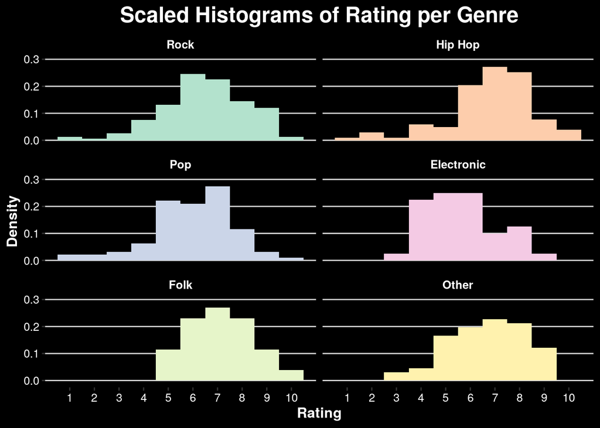

```r
generaother <- function(x) {
    if (x %in% c("Rock", "Hip Hop", "Pop", "Electronic", "Folk")) {
        x
    } else {
        "Other"
    }
}

data_full %>% mutate(Genera = sapply(Genera, generaother)) %>%
    mutate(Genera = factor(Genera, levels = c("Rock", "Hip Hop",
        "Pop", "Electronic", "Folk", "Other"))) %>% ggplot(aes(x = Rating,
    fill = Genera)) + geom_histogram(aes(y = ..density..), binwidth = 1) +
    facet_wrap(vars(Genera), nrow = 3) + scale_x_continuous(breaks = 1:10) +
    scale_y_continuous(limits = c(-0.01, 0.3)) + labs(title = "Scaled Histograms of Rating per Genre",
    x = "Rating", y = "Density") +

theme_hc() + scale_fill_brewer(palette = "Pastel2") + theme(plot.background = element_rect(fill = "black"),
    plot.title = element_text(size = rel(1.5), color = "white",
        face = "bold", hjust = 0.5), axis.text = element_text(size = rel(0.8),
        colour = "white"), axis.title.x = element_text(colour = "white",
        face = "bold"), axis.title.y = element_text(colour = "white",
        face = "bold"), strip.background = element_rect(fill = "black"),
    strip.text = element_text(colour = "white", face = "bold"),
    legend.position = "none")
```

This first plot depicts density-based histograms of ratings split up by generic genre. As a result, we can see the various rating distributions across genres. some observations: Rock is the most spread out genre, with a lot of variability in the rating that a rock album may receive. Hip hop, pop, and electronic have fairly narrow distributions, with each genre having a clear mode of around 3 rating values. Folk is easily the highest rated out of these categories, with not a single folk album getting a rating under 5.

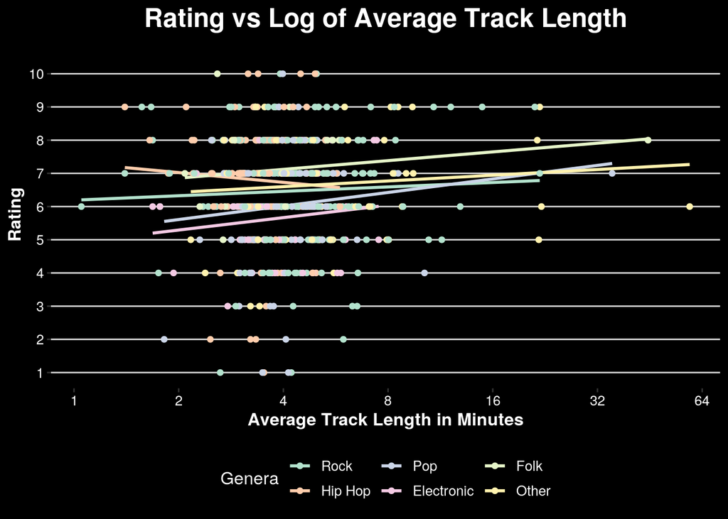

```r
data_full %>% mutate(Genera = sapply(Genera, generaother)) %>%
    mutate(Genera = factor(Genera, levels = c("Rock", "Hip Hop",
        "Pop", "Electronic", "Folk", "Other"))) %>% mutate(TrackLengthNum = sapply(TrackLength,
    conv_to_mins)) %>%
ggplot(aes(x = log(TrackLengthNum), y = Rating, color = Genera)) +
    geom_smooth(method = "lm", fill = NA) + geom_point() + scale_x_continuous(breaks = log(c(1,
    2, 4, 8, 16, 32, 64, 128)), labels = c(1, 2, 4, 8, 16, 32,
    64, 128)) + scale_y_continuous(breaks = 1:10) + labs(title = "Rating vs Log of Average Track Length",
    x = "Average Track Length in Minutes") +

theme_hc() + scale_color_brewer(palette = "Pastel2") + theme(plot.background = element_rect(fill = "black"),
    plot.title = element_text(size = rel(1.5), color = "white",
        face = "bold", hjust = 0.5), axis.text = element_text(size = rel(0.8),
        colour = "white"), axis.title.x = element_text(colour = "white",
        face = "bold"), axis.title.y = element_text(colour = "white",
        face = "bold"), strip.background = element_rect(fill = "black"),
    strip.text = element_text(colour = "white", face = "bold"),
    legend.background = element_rect(fill = "black"), legend.title = element_text(color = "white"),
    legend.text = element_text(color = "white"))
```